# Telemetria (A) vs AgentRx (B) — análise das RQs

06/07/2026

**MAS:** Gemma3-27B | **Juiz:** judge-codex-gpt-5-5 | **n = 30 cenários** (pareados por cenário, 2 braços).

A pergunta de pesquisa: *a telemetria (braço A) ajuda o juiz a **localizar** (passo) e **classificar** (categoria) a falha, comparada à baseline do artigo (braço B)?* Cada linha do `metricas.csv` é um cenário × braço; as métricas booleanas já vêm agregadas sobre as 3 reps pelo coletor (PRD-10). Resultado nulo é achado válido (PRD-00 §2).

## Campos que importam

Das 30 colunas, a análise usa um núcleo; o resto é contexto, redundância de multi-falha (seu MAS injeta 1 falha/cenário, então `earliest`/`terminal` = `critical`) ou dispersão.

| Campo | Significado |
| --- | --- |
| step_acc_exact | round(passo médio) == passo do gabarito? (endpoint RQ1) |
| step_acc_tol{1,3,5} | acerto de passo com tolerância ±k (mostra o efeito-teto) |
| avg_step_distance(_norm) |  |
| cat_acc_critical | moda das categorias preditas == categoria injetada? (endpoint RQ2) |
| cat_acc_any | categoria injetada ∈ conjunto predito (leniente) |
| most_common_category | moda das failure-cases (pool das reps); fora de {1,2,3,4,9} = fora do escopo |

## Resumo por braço

| Metrica | Telemetria (A) | AgentRx (B) | Δ (A−B) | Melhor |
| --- | --- | --- | --- | --- |
| Passo exato | 0.667 | 0.767 | -0.100 | B |
| Passo ±1 | 0.900 | 0.967 | -0.067 | B |
| Passo ±3 | 1.000 | 1.000 | 0.000 | empate |
| Passo ±5 | 1.000 | 1.000 | 0.000 | empate |
| Dist. passo (média) | 0.489 | 0.322 | 0.167 | B |
| Dist. passo (norm.) | 0.098 | 0.064 | 0.033 | B |
| Categoria crítica | 0.800 | 0.833 | -0.033 | B |
| Categoria (any) | 0.800 | 0.833 | -0.033 | B |

## Métricas-chave

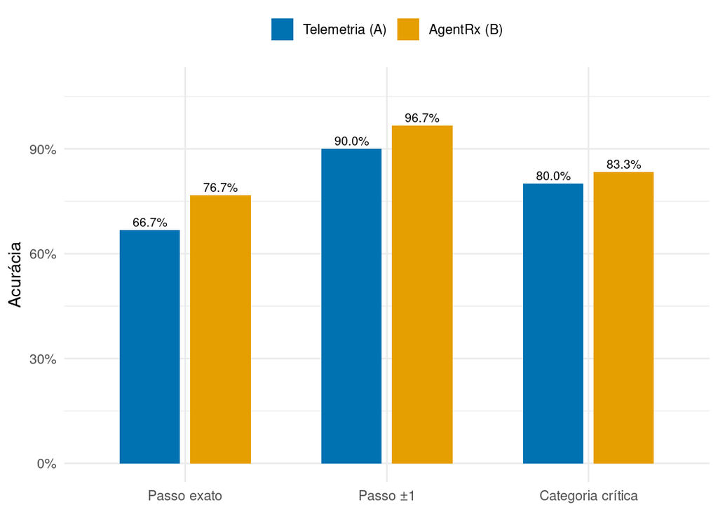

## Localização por tolerância (efeito-teto)

A acurácia de passo satura em ±3: a tarefa é fácil em tolerância frouxa, e não sobra espaço para a telemetria ajudar.

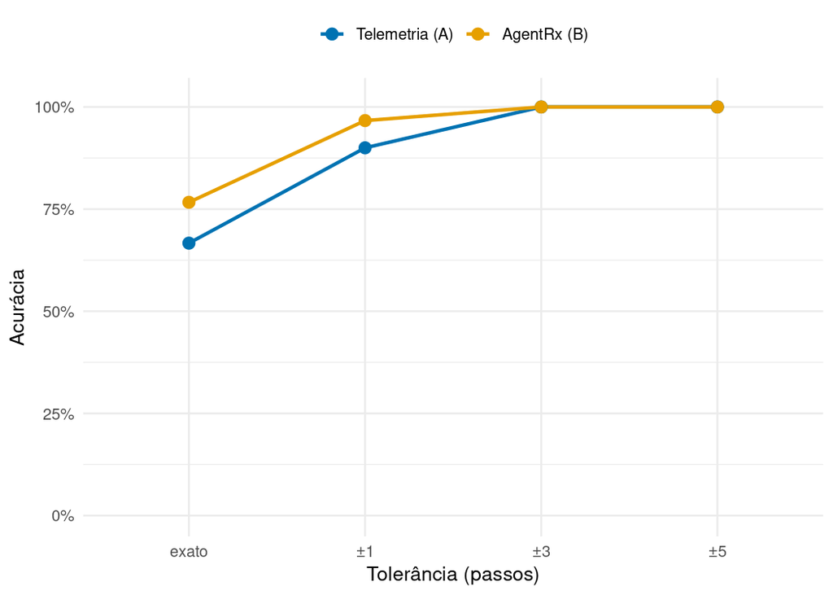

## Dispersão do erro de localização

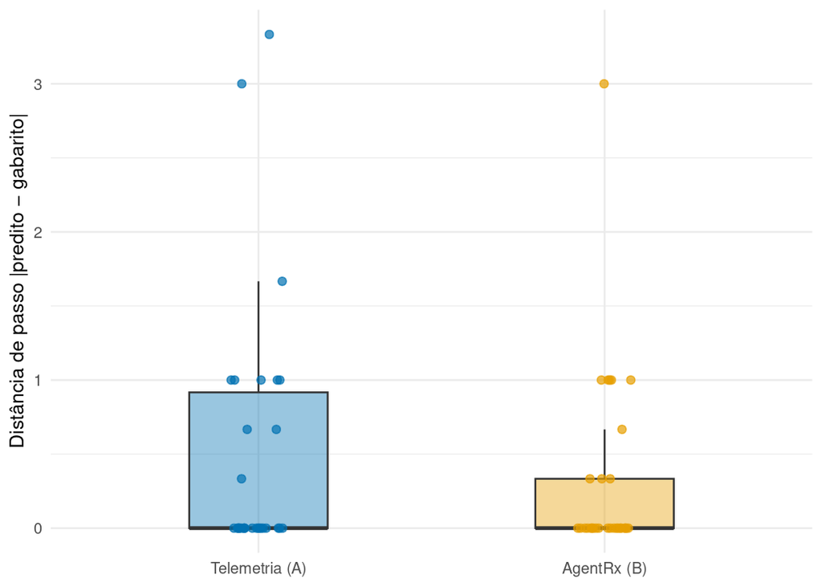

## Categoria por tipo de falha (H1/H2)

Semânticas (Misinterpretation, Invention, Plan) vs superfície (System, Invalid).

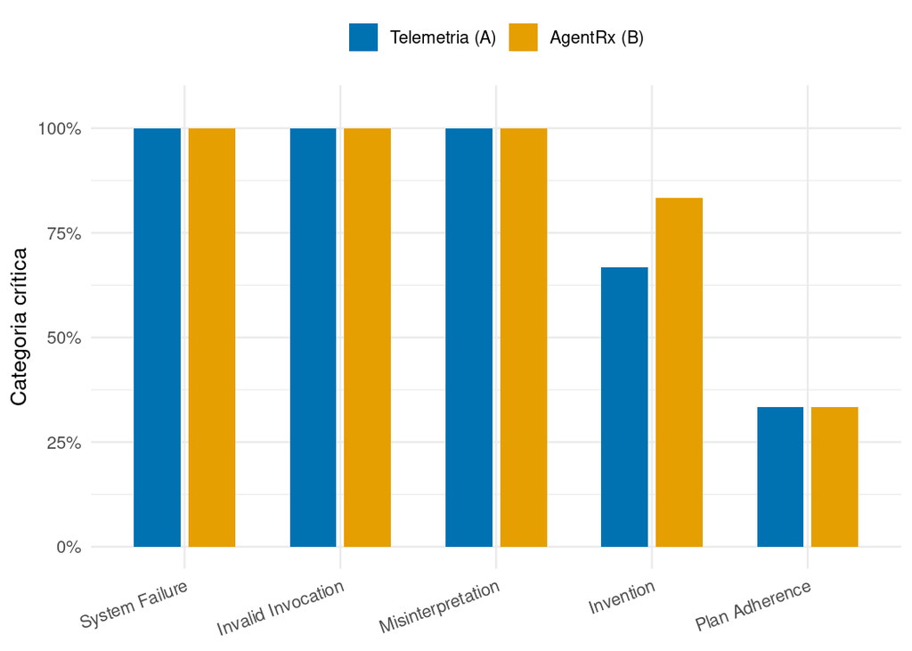

| Categoria | Braço | Cat. crítica | Passo exato | Dist. passo |
| --- | --- | --- | --- | --- |
| System Failure | Telemetria (A) | 1.000 | 1.000 | 0.000 |
| System Failure | AgentRx (B) | 1.000 | 1.000 | 0.000 |
| Invalid Invocation | Telemetria (A) | 1.000 | 0.000 | 0.889 |
| Invalid Invocation | AgentRx (B) | 1.000 | 0.500 | 0.556 |
| Misinterpretation | Telemetria (A) | 1.000 | 1.000 | 0.000 |
| Misinterpretation | AgentRx (B) | 1.000 | 1.000 | 0.000 |
| Invention | Telemetria (A) | 0.667 | 1.000 | 0.000 |
| Invention | AgentRx (B) | 0.833 | 1.000 | 0.000 |
| Plan Adherence | Telemetria (A) | 0.333 | 0.333 | 1.556 |
| Plan Adherence | AgentRx (B) | 0.333 | 0.333 | 1.056 |

## Dispersão pareada por cenário

Cada ponto é um cenário; **acima da linha tracejada = a telemetria errou mais** que a baseline naquele cenário.

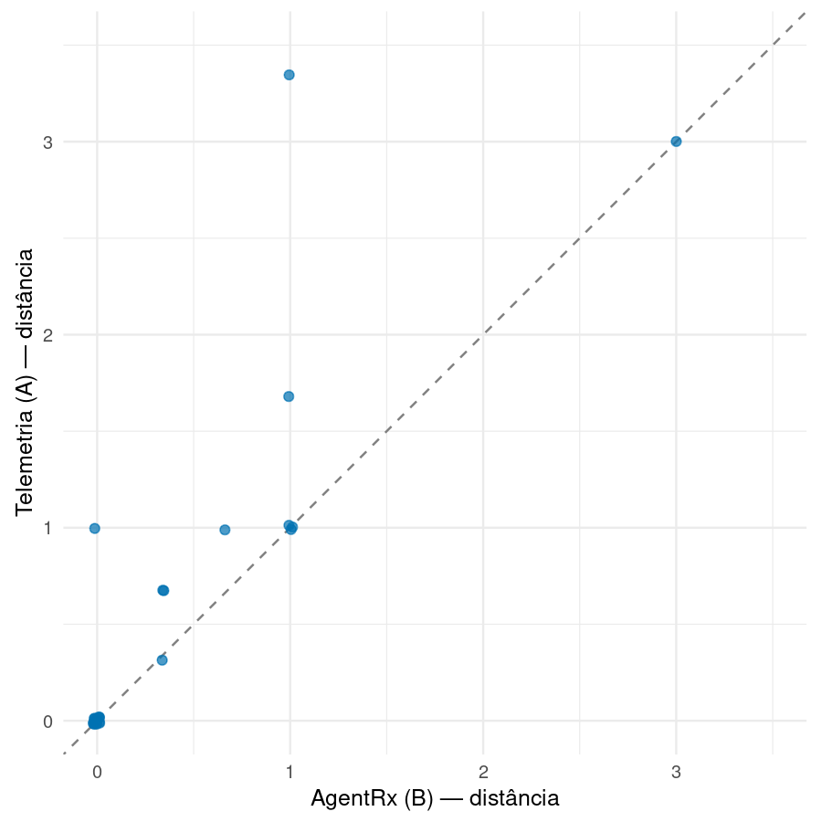

## Pareado e estatística

| Metrica | A vence | B vence | Empate |
| --- | --- | --- | --- |
| cat_acc_critical | 0 | 1 | 29 |
| step_acc_exact | 0 | 3 | 27 |
| avg_step_distance | 0 | 6 | 24 |

Vitórias pareadas (de 30 cenários)

| arm_lab | Fora do escopo | De |
| --- | --- | --- |
| Telemetria (A) | 3 | 30 |
| AgentRx (B) | 3 | 30 |

Vereditos fora das 5 categorias injetáveis

- **McNemar (categoria crítica):** discordâncias A-certo/B-errado = 0, A-errado/B-certo = 1; p = **1.000**.
- **Distância de passo — Δ médio (A−B), IC95% bootstrap:** **+0.167** [+0.033, +0.345]. Δ>0 = telemetria **pior**; IC não inclui zero.

## Conclusão

Sobre 30 cenários pareados, a telemetria **não superou** a baseline em nenhuma métrica de manchete. A **categoria** ficou empatada (McNemar p = 1.000, sem evidência de diferença); a **localização** teve efeito negativo pequeno e distinguível de zero na distância de passo (Δ = +0.167). O padrão sustenta que a telemetria-como-texto, mesmo estruturada e enriquecida, **não ajuda** este juiz — e tende a distrair de leve.

**Ressalvas:** 1 juiz, 1 MAS, n = 30; efeito-teto em ±3; o IC bootstrap é sugestivo, não confirmatório. Um segundo juiz sobre o mesmo corpus daria robustez.